# EXPLORATORY DATA ANALYSIS ON RETAIL DATASET

**LEECHITA G**

```python
import pandas as pd
```

```python
df2=pd.read_csv(r'C:\Users\Leechita G\Desktop\leems\INTERN June 2023\TASKS\SampleSuperstore.csv') #import data as dataframe
```

# OVERALL DATA

```python
df2.head()
```

|  | Ship Mode | Segment | Country | City | State | Postal Code | Region | Category | Sub-Category | Sales | Quantity | Discount | Profit |
| --- | --- | --- | --- | --- | --- | --- | --- | --- | --- | --- | --- | --- | --- |
| 0 | Second Class | Consumer | United States | Henderson | Kentucky | 42420 | South | Furniture | Bookcases | 261.9600 | 2 | 0.00 | 41.9136 |
| 1 | Second Class | Consumer | United States | Henderson | Kentucky | 42420 | South | Furniture | Chairs | 731.9400 | 3 | 0.00 | 219.5820 |
| 2 | Second Class | Corporate | United States | Los Angeles | California | 90036 | West | Office Supplies | Labels | 14.6200 | 2 | 0.00 | 6.8714 |
| 3 | Standard Class | Consumer | United States | Fort Lauderdale | Florida | 33311 | South | Furniture | Tables | 957.5775 | 5 | 0.45 | -383.0310 |
| 4 | Standard Class | Consumer | United States | Fort Lauderdale | Florida | 33311 | South | Office Supplies | Storage | 22.3680 | 2 | 0.20 | 2.5164 |

# DATA CLEANING

Checking if there are any null values in dataset

```python
null= df2.isnull().sum().sum()
print(null)
```

```
0
```

Since the number of missing values is 0, we can procceed to the next step as the data is already clean.

Remove unnecessary columns

```python
df2=df2.drop(['Country','Postal Code'],axis=1)               #dropped country since all are in the US and dropped Postal Code since it is of no use for EDA.
df2
```

|  | Ship Mode | Segment | City | State | Region | Category | Sub-Category | Sales | Quantity | Discount | Profit |
| --- | --- | --- | --- | --- | --- | --- | --- | --- | --- | --- | --- |
| 0 | Second Class | Consumer | Henderson | Kentucky | South | Furniture | Bookcases | 261.9600 | 2 | 0.00 | 41.9136 |
| 1 | Second Class | Consumer | Henderson | Kentucky | South | Furniture | Chairs | 731.9400 | 3 | 0.00 | 219.5820 |
| 2 | Second Class | Corporate | Los Angeles | California | West | Office Supplies | Labels | 14.6200 | 2 | 0.00 | 6.8714 |
| 3 | Standard Class | Consumer | Fort Lauderdale | Florida | South | Furniture | Tables | 957.5775 | 5 | 0.45 | -383.0310 |
| 4 | Standard Class | Consumer | Fort Lauderdale | Florida | South | Office Supplies | Storage | 22.3680 | 2 | 0.20 | 2.5164 |
| ... | ... | ... | ... | ... | ... | ... | ... | ... | ... | ... | ... |
| 9989 | Second Class | Consumer | Miami | Florida | South | Furniture | Furnishings | 25.2480 | 3 | 0.20 | 4.1028 |
| 9990 | Standard Class | Consumer | Costa Mesa | California | West | Furniture | Furnishings | 91.9600 | 2 | 0.00 | 15.6332 |
| 9991 | Standard Class | Consumer | Costa Mesa | California | West | Technology | Phones | 258.5760 | 2 | 0.20 | 19.3932 |
| 9992 | Standard Class | Consumer | Costa Mesa | California | West | Office Supplies | Paper | 29.6000 | 4 | 0.00 | 13.3200 |
| 9993 | Second Class | Consumer | Westminster | California | West | Office Supplies | Appliances | 243.1600 | 2 | 0.00 | 72.9480 |

9994 rows × 11 columns

```python
df2['Sales']= round(df2['Sales'],2)                             #round off to 2 decimal places
df2['Profit']= round(df2['Profit'],2)
df2
```

|  | Ship Mode | Segment | City | State | Region | Category | Sub-Category | Sales | Quantity | Discount | Profit |
| --- | --- | --- | --- | --- | --- | --- | --- | --- | --- | --- | --- |
| 0 | Second Class | Consumer | Henderson | Kentucky | South | Furniture | Bookcases | 261.96 | 2 | 0.00 | 41.91 |
| 1 | Second Class | Consumer | Henderson | Kentucky | South | Furniture | Chairs | 731.94 | 3 | 0.00 | 219.58 |
| 2 | Second Class | Corporate | Los Angeles | California | West | Office Supplies | Labels | 14.62 | 2 | 0.00 | 6.87 |
| 3 | Standard Class | Consumer | Fort Lauderdale | Florida | South | Furniture | Tables | 957.58 | 5 | 0.45 | -383.03 |
| 4 | Standard Class | Consumer | Fort Lauderdale | Florida | South | Office Supplies | Storage | 22.37 | 2 | 0.20 | 2.52 |
| ... | ... | ... | ... | ... | ... | ... | ... | ... | ... | ... | ... |
| 9989 | Second Class | Consumer | Miami | Florida | South | Furniture | Furnishings | 25.25 | 3 | 0.20 | 4.10 |
| 9990 | Standard Class | Consumer | Costa Mesa | California | West | Furniture | Furnishings | 91.96 | 2 | 0.00 | 15.63 |
| 9991 | Standard Class | Consumer | Costa Mesa | California | West | Technology | Phones | 258.58 | 2 | 0.20 | 19.39 |
| 9992 | Standard Class | Consumer | Costa Mesa | California | West | Office Supplies | Paper | 29.60 | 4 | 0.00 | 13.32 |
| 9993 | Second Class | Consumer | Westminster | California | West | Office Supplies | Appliances | 243.16 | 2 | 0.00 | 72.95 |

9994 rows × 11 columns

The Sales and Profit values are rounded off to 2 decimal points.

```python
df2.describe()
```

|  | Sales | Quantity | Discount | Profit |
| --- | --- | --- | --- | --- |
| count | 9994.000000 | 9994.000000 | 9994.000000 | 9994.000000 |
| mean | 229.857980 | 3.789574 | 0.156203 | 28.656848 |
| std | 623.245104 | 2.225110 | 0.206452 | 234.260149 |
| min | 0.440000 | 1.000000 | 0.000000 | -6599.980000 |
| 25% | 17.280000 | 2.000000 | 0.000000 | 1.730000 |
| 50% | 54.490000 | 3.000000 | 0.200000 | 8.665000 |
| 75% | 209.940000 | 5.000000 | 0.200000 | 29.360000 |
| max | 22638.480000 | 14.000000 | 0.800000 | 8399.980000 |

# CORRELATION

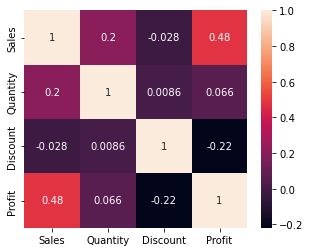

```python
import seaborn as sns                                         #correlation between attributes
import matplotlib.pyplot  as plt
plt.figure(figsize=(5,4))
sns.heatmap(df2.corr(),annot=True)
```

We can analyse the following:

1. Sales and quantity shows weak positive correlation.
2. Sales and Profit show moderate positive correlation.
3. Sales,Profit show weak negative correlation with Discount.
4. Profit and Quantity show weak positive correlation.

```python
df2.corr()['Sales'].round(2)
```

```
Sales       1.00
Quantity    0.20
Discount   -0.03
Profit      0.48
Name: Sales, dtype: float64
```

# NO OF DISTINCT COLUMNS

```python
#finding all unique columns
```

```python
uniqueval=df2.nunique()
print(uniqueval)
print(type(uniqueval))
```

```
Ship Mode          4
Segment            3
City             531
State             49
Region             4
Category           3
Sub-Category      17
Sales           5456
Quantity          14
Discount          12
Profit          5155
dtype: int64
<class 'pandas.core.series.Series'>
```

# FINDING UNIQUE RECORDS OF EACH COLUMN

```python
print("Ship Mode : ",df2["Ship Mode"].unique())
print("Segment : ",df2["Segment"].unique())
print("City : ",df2["City"].unique())
print("State : ",df2["State"].unique())
print("Region : ",df2["Region"].unique())
print("Category : ",df2["Category"].unique())
print("Sub-Category : ",df2["Sub-Category"].unique())
print("Quantity : ",df2["Quantity"].unique())
print("Discount : ",df2["Discount"].unique())
```

```
Ship Mode :  ['Second Class' 'Standard Class' 'First Class' 'Same Day']
Segment :  ['Consumer' 'Corporate' 'Home Office']
City :  ['Henderson' 'Los Angeles' 'Fort Lauderdale' 'Concord' 'Seattle'
 'Fort Worth' 'Madison' 'West Jordan' 'San Francisco' 'Fremont'
 'Philadelphia' 'Orem' 'Houston' 'Richardson' 'Naperville' 'Melbourne'
 'Eagan' 'Westland' 'Dover' 'New Albany' 'New York City' 'Troy' 'Chicago'
 'Gilbert' 'Springfield' 'Jackson' 'Memphis' 'Decatur' 'Durham' 'Columbia'
 'Rochester' 'Minneapolis' 'Portland' 'Saint Paul' 'Aurora' 'Charlotte'
 'Orland Park' 'Urbandale' 'Columbus' 'Bristol' 'Wilmington' 'Bloomington'
 'Phoenix' 'Roseville' 'Independence' 'Pasadena' 'Newark' 'Franklin'
 'Scottsdale' 'San Jose' 'Edmond' 'Carlsbad' 'San Antonio' 'Monroe'
 'Fairfield' 'Grand Prairie' 'Redlands' 'Hamilton' 'Westfield' 'Akron'
 'Denver' 'Dallas' 'Whittier' 'Saginaw' 'Medina' 'Dublin' 'Detroit'
 'Tampa' 'Santa Clara' 'Lakeville' 'San Diego' 'Brentwood' 'Chapel Hill'
 'Morristown' 'Cincinnati' 'Inglewood' 'Tamarac' 'Colorado Springs'
 'Belleville' 'Taylor' 'Lakewood' 'Arlington' 'Arvada' 'Hackensack'
 'Saint Petersburg' 'Long Beach' 'Hesperia' 'Murfreesboro' 'Layton'
 'Austin' 'Lowell' 'Manchester' 'Harlingen' 'Tucson' 'Quincy'
 'Pembroke Pines' 'Des Moines' 'Peoria' 'Las Vegas' 'Warwick' 'Miami'
 'Huntington Beach' 'Richmond' 'Louisville' 'Lawrence' 'Canton'
 'New Rochelle' 'Gastonia' 'Jacksonville' 'Auburn' 'Norman' 'Park Ridge'
 'Amarillo' 'Lindenhurst' 'Huntsville' 'Fayetteville' 'Costa Mesa'
 'Parker' 'Atlanta' 'Gladstone' 'Great Falls' 'Lakeland' 'Montgomery'
 'Mesa' 'Green Bay' 'Anaheim' 'Marysville' 'Salem' 'Laredo' 'Grove City'
 'Dearborn' 'Warner Robins' 'Vallejo' 'Mission Viejo' 'Rochester Hills'
 'Plainfield' 'Sierra Vista' 'Vancouver' 'Cleveland' 'Tyler' 'Burlington'
 'Waynesboro' 'Chester' 'Cary' 'Palm Coast' 'Mount Vernon' 'Hialeah'
 'Oceanside' 'Evanston' 'Trenton' 'Cottage Grove' 'Bossier City'
 'Lancaster' 'Asheville' 'Lake Elsinore' 'Omaha' 'Edmonds' 'Santa Ana'
 'Milwaukee' 'Florence' 'Lorain' 'Linden' 'Salinas' 'New Brunswick'
 'Garland' 'Norwich' 'Alexandria' 'Toledo' 'Farmington' 'Riverside'
 'Torrance' 'Round Rock' 'Boca Raton' 'Virginia Beach' 'Murrieta'
 'Olympia' 'Washington' 'Jefferson City' 'Saint Peters' 'Rockford'
 'Brownsville' 'Yonkers' 'Oakland' 'Clinton' 'Encinitas' 'Roswell'
 'Jonesboro' 'Antioch' 'Homestead' 'La Porte' 'Lansing' 'Cuyahoga Falls'
 'Reno' 'Harrisonburg' 'Escondido' 'Royal Oak' 'Rockville' 'Coral Springs'
 'Buffalo' 'Boynton Beach' 'Gulfport' 'Fresno' 'Greenville' 'Macon'
 'Cedar Rapids' 'Providence' 'Pueblo' 'Deltona' 'Murray' 'Middletown'
 'Freeport' 'Pico Rivera' 'Provo' 'Pleasant Grove' 'Smyrna' 'Parma'
 'Mobile' 'New Bedford' 'Irving' 'Vineland' 'Glendale' 'Niagara Falls'
```

[output cut: 56 more lines]

```
 'Wisconsin' 'Utah' 'Nebraska' 'Pennsylvania' 'Illinois' 'Minnesota'
 'Michigan' 'Delaware' 'Indiana' 'New York' 'Arizona' 'Virginia'
 'Tennessee' 'Alabama' 'South Carolina' 'Oregon' 'Colorado' 'Iowa' 'Ohio'
 'Missouri' 'Oklahoma' 'New Mexico' 'Louisiana' 'Connecticut' 'New Jersey'
 'Massachusetts' 'Georgia' 'Nevada' 'Rhode Island' 'Mississippi'
 'Arkansas' 'Montana' 'New Hampshire' 'Maryland' 'District of Columbia'
 'Kansas' 'Vermont' 'Maine' 'South Dakota' 'Idaho' 'North Dakota'
 'Wyoming' 'West Virginia']
Region :  ['South' 'West' 'Central' 'East']
Category :  ['Furniture' 'Office Supplies' 'Technology']
Sub-Category :  ['Bookcases' 'Chairs' 'Labels' 'Tables' 'Storage' 'Furnishings' 'Art'
 'Phones' 'Binders' 'Appliances' 'Paper' 'Accessories' 'Envelopes'
 'Fasteners' 'Supplies' 'Machines' 'Copiers']
Quantity :  [ 2  3  5  7  4  6  9  1  8 14 11 13 10 12]
Discount :  [0.   0.45 0.2  0.8  0.3  0.5  0.7  0.6  0.32 0.1  0.4  0.15]
```

We will analyse the retail sales of products sold to various cities in the US.

# SHIP MODE

SALES

```python
ser1 = df2.groupby(by=['Ship Mode'])['Sales'].sum()
#converting series to Data Frame
ser1_df = ser1.reset_index()
print(ser1_df)
```

```
        Ship Mode       Sales
0     First Class   351428.32
1        Same Day   128363.09
2    Second Class   459193.40
3  Standard Class  1358215.84
```

```python
print(ser1_df.sort_values(by="Sales",ascending=True))
min=ser1_df.loc[ser1_df['Sales'] == ser1_df['Sales'].min()]
max=ser1_df.loc[ser1_df['Sales'] == ser1_df['Sales'].max()]
```

```
        Ship Mode       Sales
1        Same Day   128363.09
0     First Class   351428.32
2    Second Class   459193.40
3  Standard Class  1358215.84
```

```python
min
```

|  | Ship Mode | Sales |
| --- | --- | --- |
| 1 | Same Day | 128363.09 |

```python
max
```

|  | Ship Mode | Sales |
| --- | --- | --- |
| 3 | Standard Class | 1358215.84 |

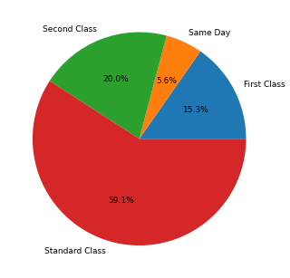

```python
from matplotlib.pyplot import figure
figure(figsize=(8,6), dpi=65)
import matplotlib.pyplot as plt
plt.pie(ser1_df['Sales'], labels = ser1_df['Ship Mode'],autopct='%0.1f%%')
plt.show()
```

SHIP MODE:

1. Less Sales: Same Day
2. More Sales: Standard Class

PROFIT

```python
ser2 = df2.groupby(by=['Ship Mode'])['Profit'].sum()
print(ser2)
print(type(ser2))
```

```
Ship Mode
First Class        48969.74
Same Day           15891.77
Second Class       57446.30
Standard Class    164088.73
Name: Profit, dtype: float64
<class 'pandas.core.series.Series'>
```

```python
ser2_df = ser2.reset_index()
print(ser2_df)
print(type(ser2_df))
```

```
        Ship Mode     Profit
0     First Class   48969.74
1        Same Day   15891.77
2    Second Class   57446.30
3  Standard Class  164088.73
<class 'pandas.core.frame.DataFrame'>
```

```python
print(ser2_df.sort_values(by="Profit",ascending=True))
min=ser2_df.loc[ser2_df['Profit'] == ser2_df['Profit'].min()]
max=ser2_df.loc[ser2_df['Profit'] == ser2_df['Profit'].max()]
```

```
        Ship Mode     Profit
1        Same Day   15891.77
0     First Class   48969.74
2    Second Class   57446.30
3  Standard Class  164088.73
```

```python
min
```

|  | Ship Mode | Profit |
| --- | --- | --- |
| 1 | Same Day | 15891.77 |

```python
max
```

|  | Ship Mode | Profit |
| --- | --- | --- |
| 3 | Standard Class | 164088.73 |

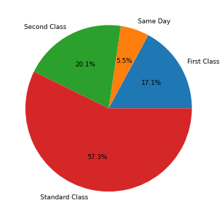

```python
from matplotlib.pyplot import figure
figure(figsize=(8,6), dpi=65)
import matplotlib.pyplot as plt
plt.pie(ser2_df['Profit'], labels = ser2_df['Ship Mode'],autopct='%0.1f%%')
plt.show()
```

SHIP MODE:

1. Less Profit: Same Day
2. More Profit: Standard Class

DISCOUNT

```python
ser3 = df2.groupby(by=['Ship Mode'])['Discount'].sum()
print(ser3)
print(type(ser3))
```

```
Ship Mode
First Class       253.17
Same Day           82.75
Second Class      270.15
Standard Class    955.02
Name: Discount, dtype: float64
<class 'pandas.core.series.Series'>
```

```python
ser3_df = ser3.reset_index()
print(ser3_df)
print(type(ser3_df))
```

```
        Ship Mode  Discount
0     First Class    253.17
1        Same Day     82.75
2    Second Class    270.15
3  Standard Class    955.02
<class 'pandas.core.frame.DataFrame'>
```

```python
print(ser3_df.sort_values(by="Discount",ascending=True))
min=ser3_df.loc[ser3_df['Discount'] == ser3_df['Discount'].min()]
max=ser3_df.loc[ser3_df['Discount'] == ser3_df['Discount'].max()]
```

```
        Ship Mode  Discount
1        Same Day     82.75
0     First Class    253.17
2    Second Class    270.15
3  Standard Class    955.02
```

```python
min
```

|  | Ship Mode | Discount |
| --- | --- | --- |
| 1 | Same Day | 82.75 |

```python
max
```

|  | Ship Mode | Discount |
| --- | --- | --- |
| 3 | Standard Class | 955.02 |

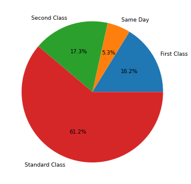

```python
from matplotlib.pyplot import figure
figure(figsize=(8,6), dpi=65)
import matplotlib.pyplot as plt
plt.pie(ser3_df['Discount'], labels = ser3_df['Ship Mode'],autopct='%0.1f%%')
plt.show()
```

SHIP MODE

1. Less Discount: Same Day
2. More Discount: Standard Class

QUANTITY

```python
ser4 = df2.groupby(by=['Ship Mode'])['Quantity'].sum()
print(ser4)
print(type(ser4))
```

```
Ship Mode
First Class        5693
Same Day           1960
Second Class       7423
Standard Class    22797
Name: Quantity, dtype: int64
<class 'pandas.core.series.Series'>
```

```python
ser4_df = ser4.reset_index()
print(ser4_df)
print(type(ser4_df))
```

```
        Ship Mode  Quantity
0     First Class      5693
1        Same Day      1960
2    Second Class      7423
3  Standard Class     22797
<class 'pandas.core.frame.DataFrame'>
```

```python
ser4_df.sort_values(by="Quantity",ascending=True)
```

|  | Ship Mode | Quantity |
| --- | --- | --- |
| 1 | Same Day | 1960 |
| 0 | First Class | 5693 |
| 2 | Second Class | 7423 |
| 3 | Standard Class | 22797 |

```python
min=ser4_df.loc[ser4_df['Quantity'] == ser4_df['Quantity'].min()]
max=ser4_df.loc[ser4_df['Quantity'] == ser4_df['Quantity'].max()]
```

```python
min
```

|  | Ship Mode | Quantity |
| --- | --- | --- |
| 1 | Same Day | 1960 |

```python
max
```

|  | Ship Mode | Quantity |
| --- | --- | --- |
| 3 | Standard Class | 22797 |

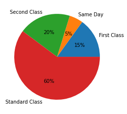

```python
plt.pie(ser4_df["Quantity"], labels = ser4_df["Ship Mode"],autopct='%1.0f%%')
plt.show()
```

SHIP MODE

1. Less qty: Same Day
2. More qty: Standard Class

**CONCLUSION: Sales,Profit,Discount,Quantity is high in Standard Class and low in Same Day**

# SEGMENT

```python
ser5 = df2.groupby(by=['Segment'])['Sales'].sum()
ser5_df = ser5.reset_index()
ser5_df.sort_values(by="Sales",ascending=True)
```

|  | Segment | Sales |
| --- | --- | --- |
| 2 | Home Office | 429653.21 |
| 1 | Corporate | 706146.32 |
| 0 | Consumer | 1161401.12 |

```python
min=ser5_df.loc[ser5_df['Sales'] == ser5_df['Sales'].min()]
min
```

|  | Segment | Sales |
| --- | --- | --- |
| 2 | Home Office | 429653.21 |

```python
max=ser5_df.loc[ser5_df['Sales'] == ser5_df['Sales'].max()]
max
```

|  | Segment | Sales |
| --- | --- | --- |
| 0 | Consumer | 1161401.12 |

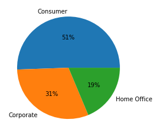

```python
plt.pie(ser5_df["Sales"], labels = ser5_df["Segment"],autopct='%1.0f%%')
plt.show()
```

1. More sales: Consumer
2. Less sales: Home Ofice

Profit

```python
ser6 = df2.groupby(by=['Segment'])['Profit'].sum()
ser6_df = ser6.reset_index()
ser6_df.sort_values(by="Profit",ascending=True)
```

|  | Segment | Profit |
| --- | --- | --- |
| 2 | Home Office | 60298.77 |
| 1 | Corporate | 91979.13 |
| 0 | Consumer | 134118.64 |

```python
min=ser6_df.loc[ser6_df['Profit'] == ser6_df['Profit'].min()]
min
```

|  | Segment | Profit |
| --- | --- | --- |
| 2 | Home Office | 60298.77 |

```python
max=ser6_df.loc[ser6_df['Profit'] == ser6_df['Profit'].max()]
max
```

|  | Segment | Profit |
| --- | --- | --- |
| 0 | Consumer | 134118.64 |

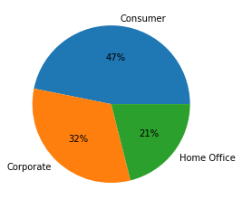

```python
plt.pie(ser6_df["Profit"], labels = ser6_df["Segment"],autopct='%1.0f%%')
plt.show()
```

1. More profit: Consumer
2. Less profit: Home Ofice

DISCOUNT

```python
ser7 = df2.groupby(by=['Segment'])['Discount'].sum()
ser7_df = ser7.reset_index()
ser7_df.sort_values(by="Discount",ascending=True)
```

|  | Segment | Discount |
| --- | --- | --- |
| 2 | Home Office | 262.33 |
| 1 | Corporate | 477.85 |
| 0 | Consumer | 820.91 |

```python
min=ser7_df.loc[ser7_df['Discount'] == ser7_df['Discount'].min()]
min
```

|  | Segment | Discount |
| --- | --- | --- |
| 2 | Home Office | 262.33 |

```python
max=ser7_df.loc[ser7_df['Discount'] == ser7_df['Discount'].max()]
max
```

|  | Segment | Discount |
| --- | --- | --- |
| 0 | Consumer | 820.91 |

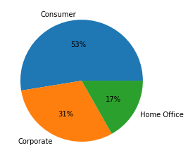

```python
plt.pie(ser7_df["Discount"], labels = ser7_df["Segment"],autopct='%1.0f%%')
plt.show()
```

1. More discount: Consumer
2. Less discount: Home Office

QUANTITY

```python
ser8 = df2.groupby(by=['Segment'])['Quantity'].sum()
ser8_df = ser8.reset_index()
ser8_df.sort_values(by="Quantity",ascending=True)
```

|  | Segment | Quantity |
| --- | --- | --- |
| 2 | Home Office | 6744 |
| 1 | Corporate | 11608 |
| 0 | Consumer | 19521 |

```python
min=ser8_df.loc[ser8_df['Quantity'] == ser8_df['Quantity'].min()]
min
```

|  | Segment | Quantity |
| --- | --- | --- |
| 2 | Home Office | 6744 |

```python
max=ser8_df.loc[ser8_df['Quantity'] == ser8_df['Quantity'].max()]
max
```

|  | Segment | Quantity |
| --- | --- | --- |
| 0 | Consumer | 19521 |

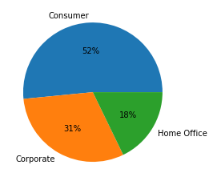

```python
plt.pie(ser8_df["Quantity"], labels = ser8_df["Segment"],autopct='%1.0f%%')
plt.show()
```

1. More Quantity: Consumer
2. Less Quantity: Home Office

**CONCLUSION: Sales,Profit,Discount and Quantity is more by Consumer and less by Home Office**

# STATE

```python
df2['State'].value_counts()
```

```
California              2001
New York                1128
Texas                    985
Pennsylvania             587
Washington               506
Illinois                 492
Ohio                     469
Florida                  383
Michigan                 255
North Carolina           249
Arizona                  224
Virginia                 224
Georgia                  184
Tennessee                183
Colorado                 182
Indiana                  149
Kentucky                 139
Massachusetts            135
New Jersey               130
Oregon                   124
Wisconsin                110
Maryland                 105
Delaware                  96
Minnesota                 89
Connecticut               82
Oklahoma                  66
Missouri                  66
Alabama                   61
Arkansas                  60
Rhode Island              56
Utah                      53
Mississippi               53
Louisiana                 42
South Carolina            42
Nevada                    39
Nebraska                  38
New Mexico                37
Iowa                      30
New Hampshire             27
Kansas                    24
Idaho                     21
Montana                   15
South Dakota              12
Vermont                   11
District of Columbia      10
Maine                      8
North Dakota               7
West Virginia              4
Wyoming                    1
Name: State, dtype: int64
```

```python
df_state= df2.groupby(['State'])[['Sales', 'Discount', 'Profit']].mean()
df_state.sort_values(by='Sales')
```

| State | Sales | Discount | Profit |
| --- | --- | --- | --- |
| South Dakota | 109.630000 | 0.000000 | 32.903333 |
| Kansas | 121.429583 | 0.000000 | 34.851667 |
| New Mexico | 129.284865 | 0.059459 | 31.273784 |
| North Dakota | 131.415714 | 0.000000 | 32.877143 |
| Oregon | 140.573548 | 0.288710 | -9.600565 |
| Iowa | 152.658667 | 0.000000 | 39.460000 |
| Arizona | 157.508661 | 0.303571 | -15.303080 |
| Maine | 158.816250 | 0.000000 | 56.811250 |
| Illinois | 162.939248 | 0.390041 | -25.625894 |
| Connecticut | 163.223902 | 0.007317 | 42.822439 |
| Ohio | 166.861812 | 0.324947 | -36.186311 |
| Tennessee | 167.551475 | 0.291257 | -29.189454 |
| Texas | 172.779604 | 0.370193 | -26.121137 |
| Colorado | 176.418187 | 0.316484 | -35.867473 |
| Arkansas | 194.635500 | 0.000000 | 66.810833 |
| Nebraska | 196.445526 | 0.000000 | 53.607632 |
| Pennsylvania | 198.487189 | 0.328620 | -26.507768 |
| South Carolina | 201.945476 | 0.000000 | 42.120714 |
| Mississippi | 203.232830 | 0.000000 | 59.867358 |
| Idaho | 208.690000 | 0.085714 | 39.368095 |
| Utah | 211.699245 | 0.060377 | 48.047925 |
| Massachusetts | 212.106963 | 0.015556 | 50.262963 |
| Louisiana | 219.453095 | 0.000000 | 52.287619 |
| North Carolina | 223.305502 | 0.283534 | -30.083695 |
| Maryland | 225.766857 | 0.005714 | 66.963524 |
| California | 228.729445 | 0.072764 | 38.171529 |
| Florida | 233.612742 | 0.299347 | -8.875352 |
| Kentucky | 263.250000 | 0.000000 | 80.573094 |
| Georgia | 266.825217 | 0.000000 | 88.315217 |
| New Hampshire | 270.093333 | 0.011111 | 63.203333 |
| Washington | 273.994644 | 0.064032 | 66.013123 |
| New Jersey | 275.110154 | 0.004615 | 75.176154 |
| New York | 275.599468 | 0.055319 | 65.636941 |
| Delaware | 285.948646 | 0.006250 | 103.930729 |
| District of Columbia | 286.502000 | 0.000000 | 105.959000 |
| Wisconsin | 291.951000 | 0.000000 | 76.379818 |
| Oklahoma | 298.233182 | 0.000000 | 73.545000 |
| Michigan | 299.096510 | 0.007059 | 95.933725 |
| West Virginia | 302.455000 | 0.075000 | 46.482500 |
| Virginia | 315.342500 | 0.000000 | 83.026741 |
| Alabama | 319.846557 | 0.000000 | 94.866230 |
| Minnesota | 335.541011 | 0.000000 | 121.609101 |
| Missouri | 336.441667 | 0.000000 | 97.518030 |
| Indiana | 359.431946 | 0.000000 | 123.375436 |
| Montana | 372.623333 | 0.066667 | 122.221333 |
| Rhode Island | 404.070714 | 0.021429 | 130.100536 |
| Nevada | 428.951282 | 0.061538 | 85.045128 |
| Vermont | 811.760909 | 0.000000 | 204.089091 |
| Wyoming | 1603.140000 | 0.200000 | 100.200000 |

```python
max=df_state.loc[df_state['Sales'] == df_state['Sales'].max()]
max
```

| State | Sales | Discount | Profit |
| --- | --- | --- | --- |
| Wyoming | 1603.14 | 0.2 | 100.2 |

```python
min=df_state.loc[df_state['Sales'] == df_state['Sales'].min()]
min
```

| State | Sales | Discount | Profit |
| --- | --- | --- | --- |
| South Dakota | 109.63 | 0.0 | 32.903333 |

```python
max=df_state.loc[df_state['Discount'] == df_state['Discount'].max()]
max
```

| State | Sales | Discount | Profit |
| --- | --- | --- | --- |
| Illinois | 162.939248 | 0.390041 | -25.625894 |

```python
min=df_state.loc[df_state['Discount'] == df_state['Discount'].min()]
min
```

| State | Sales | Discount | Profit |
| --- | --- | --- | --- |
| Alabama | 319.846557 | 0.0 | 94.866230 |
| Arkansas | 194.635500 | 0.0 | 66.810833 |
| District of Columbia | 286.502000 | 0.0 | 105.959000 |
| Georgia | 266.825217 | 0.0 | 88.315217 |
| Indiana | 359.431946 | 0.0 | 123.375436 |
| Iowa | 152.658667 | 0.0 | 39.460000 |
| Kansas | 121.429583 | 0.0 | 34.851667 |
| Kentucky | 263.250000 | 0.0 | 80.573094 |
| Louisiana | 219.453095 | 0.0 | 52.287619 |
| Maine | 158.816250 | 0.0 | 56.811250 |
| Minnesota | 335.541011 | 0.0 | 121.609101 |
| Mississippi | 203.232830 | 0.0 | 59.867358 |
| Missouri | 336.441667 | 0.0 | 97.518030 |
| Nebraska | 196.445526 | 0.0 | 53.607632 |
| North Dakota | 131.415714 | 0.0 | 32.877143 |
| Oklahoma | 298.233182 | 0.0 | 73.545000 |
| South Carolina | 201.945476 | 0.0 | 42.120714 |
| South Dakota | 109.630000 | 0.0 | 32.903333 |
| Vermont | 811.760909 | 0.0 | 204.089091 |
| Virginia | 315.342500 | 0.0 | 83.026741 |
| Wisconsin | 291.951000 | 0.0 | 76.379818 |

```python
max=df_state.loc[df_state['Profit'] == df_state['Profit'].max()]
max
```

| State | Sales | Discount | Profit |
| --- | --- | --- | --- |
| Vermont | 811.760909 | 0.0 | 204.089091 |

```python
min=df_state.loc[df_state['Profit'] == df_state['Profit'].min()]
min
```

| State | Sales | Discount | Profit |
| --- | --- | --- | --- |
| Ohio | 166.861812 | 0.324947 | -36.186311 |

SALES:

1. Highest Sales: Wyoming
2. Lowest Sales: South Dakota
3. Highest Discount:Illinois
4. Lowest Discount: Represented below in Graph
5. Highest Profit: Vermont
6. Lowest Profit: Ohio

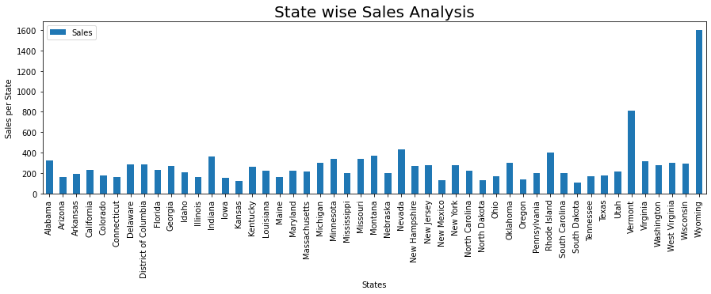

```python
df_state[['Sales']].plot(kind = 'bar', figsize = (15,4))
plt.title('State wise Sales Analysis', fontsize = 20)
plt.ylabel('Sales per State')
plt.xlabel('States')
plt.show()
```

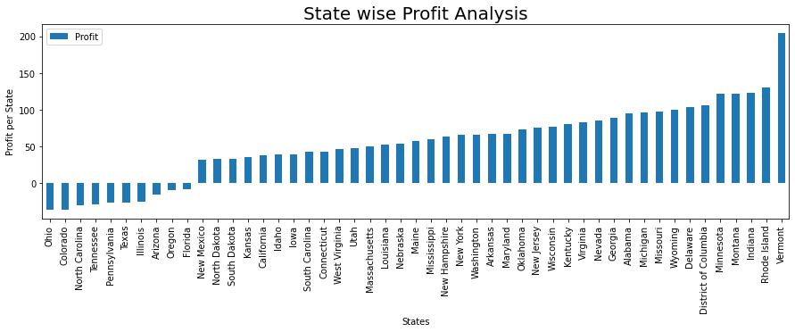

```python
df_state=df_state.sort_values('Profit')
df_state[['Profit']].plot(kind = 'bar', figsize = (15,4))
plt.title('State wise Profit Analysis', fontsize = 20)
plt.ylabel('Profit per State')
plt.xlabel('States')
plt.show()
```

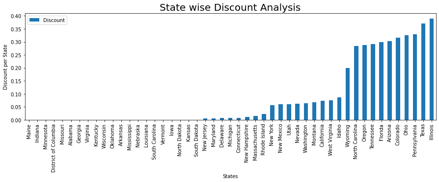

```python
df_state=df_state.sort_values('Discount')
df_state[['Discount']].plot(kind = 'bar', figsize = (15,4))
plt.title('State wise Discount Analysis', fontsize = 20)
plt.ylabel('Discount per State')
plt.xlabel('States')
plt.show()
```

# CITY

```python
df_city= df2.groupby(['City'])[['Sales', 'Discount', 'Profit']].mean()
df_city = df_city.sort_values('Sales')
df_city.head()
```

| City | Sales | Discount | Profit |
| --- | --- | --- | --- |
| Abilene | 1.39 | 0.8 | -3.76 |
| Elyria | 1.82 | 0.7 | -1.40 |
| Jupiter | 2.06 | 0.2 | 0.15 |
| Pensacola | 2.21 | 0.7 | -1.48 |
| Ormond Beach | 2.81 | 0.7 | -1.97 |

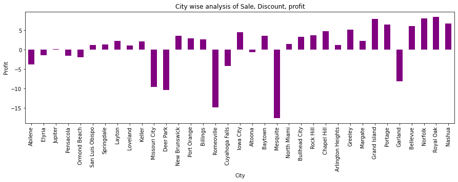

```python
df_city['Profit'].head(35).plot(kind='bar',figsize=(15,4),color = 'Purple')
plt.title('City wise analysis of Sale, Discount, profit')
plt.xlabel('City')
plt.ylabel('Profit')
```

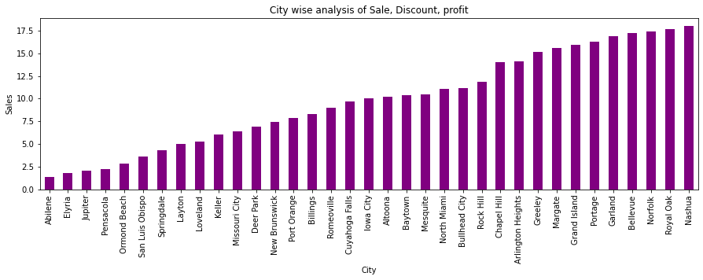

```python
df_city['Sales'].head(35).plot(kind='bar',figsize=(15,4),color = 'Purple')
plt.title('City wise analysis of Sale, Discount, profit')
plt.xlabel('City')
plt.ylabel('Sales')
```

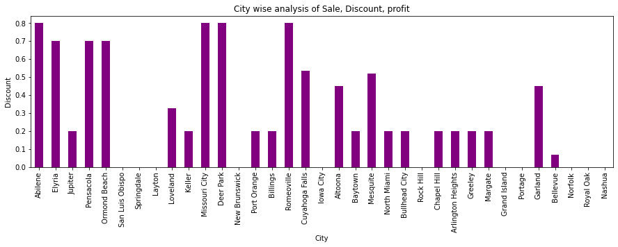

```python
df_city['Discount'].head(35).plot(kind='bar',figsize=(15,4),color = 'Purple')
plt.title('City wise analysis of Sale, Discount, profit')
plt.xlabel('City')
plt.ylabel('Discount')
```

# REGION

```python
df_region= df2.groupby(['Region'])[['Sales', 'Discount', 'Profit','Quantity']].mean()
df_region = df_region.sort_values('Sales')
df_region
```

| Region | Sales | Discount | Profit | Quantity |
| --- | --- | --- | --- | --- |
| Central | 215.772604 | 0.240353 | 17.092656 | 3.779595 |
| West | 226.493213 | 0.109335 | 33.848988 | 3.829535 |
| East | 238.336131 | 0.145365 | 32.135709 | 3.728230 |
| South | 241.803599 | 0.147253 | 28.857710 | 3.832716 |

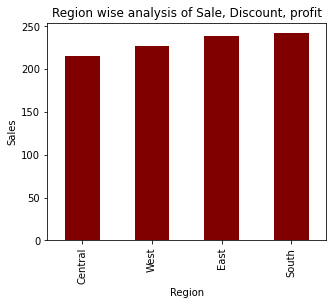

```python
df_region['Sales'].plot(kind='bar',figsize=(5,4),color = 'Maroon')
plt.title('Region wise analysis of Sale, Discount, profit')
plt.xlabel('Region')
plt.ylabel('Sales')
```

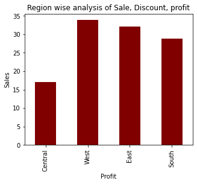

```python
df_region['Profit'].plot(kind='bar',figsize=(5,4),color = 'Maroon')
plt.title('Region wise analysis of Sale, Discount, profit')
plt.xlabel('Profit')
plt.ylabel('Sales')
```

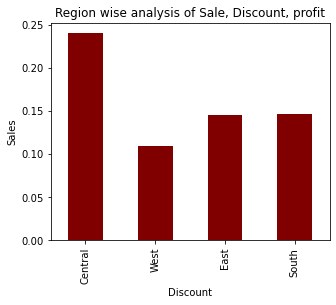

```python
df_region['Discount'].plot(kind='bar',figsize=(5,4),color = 'Maroon')
plt.title('Region wise analysis of Sale, Discount, profit')
plt.xlabel('Discount')
plt.ylabel('Sales')
```

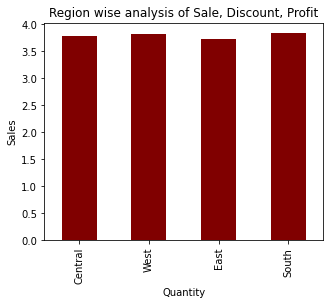

```python
df_region['Quantity'].plot(kind='bar',figsize=(5,4),color = 'Maroon')
plt.title('Region wise analysis of Sale, Discount, Profit')
plt.xlabel('Quantity')
plt.ylabel('Sales')
```

```python
max=df_region.loc[df_region['Quantity'] == df_region['Quantity'].max()]
max
```

| Region | Sales | Discount | Profit | Quantity |
| --- | --- | --- | --- | --- |
| South | 241.803599 | 0.147253 | 28.85771 | 3.832716 |

```python
min=df_region.loc[df_region['Quantity'] == df_region['Quantity'].min()]
min
```

| Region | Sales | Discount | Profit | Quantity |
| --- | --- | --- | --- | --- |
| East | 238.336131 | 0.145365 | 32.135709 | 3.72823 |

# CATEGORY

```python
df_category= df2.groupby(['Category'])[['Sales', 'Discount', 'Profit','Quantity']].mean()
df_category= df_category.sort_values('Sales')
df_category
```

| Category | Sales | Discount | Profit | Quantity |
| --- | --- | --- | --- | --- |
| Office Supplies | 119.324079 | 0.157285 | 20.326917 | 3.801195 |
| Furniture | 349.834856 | 0.173923 | 8.699246 | 3.785007 |
| Technology | 452.709269 | 0.132323 | 78.752269 | 3.756903 |

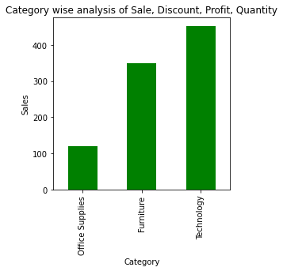

```python
df_category['Sales'].plot(kind='bar',figsize=(4,4),color = 'Green')
plt.title('Category wise analysis of Sale, Discount, Profit, Quantity')
plt.xlabel('Category')
plt.ylabel('Sales')
```

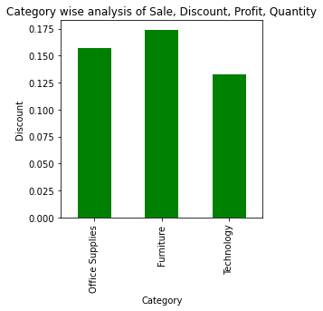

```python
df_category['Discount'].plot(kind='bar',figsize=(4,4),color = 'Green')
plt.title('Category wise analysis of Sale, Discount, Profit, Quantity')
plt.xlabel('Category')
plt.ylabel('Discount')
```

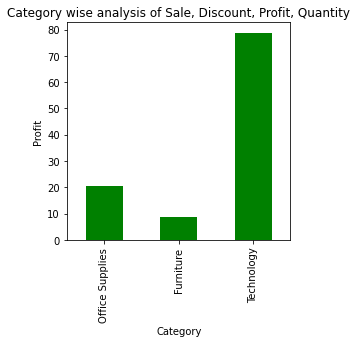

```python
df_category['Profit'].plot(kind='bar',figsize=(4,4),color = 'Green')
plt.title('Category wise analysis of Sale, Discount, Profit, Quantity')
plt.xlabel('Category')
plt.ylabel('Profit')
```

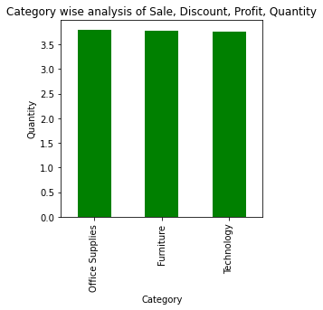

```python
df_category['Quantity'].plot(kind='bar',figsize=(4,4),color = 'Green')
plt.title('Category wise analysis of Sale, Discount, Profit, Quantity')
plt.xlabel('Category')
plt.ylabel('Quantity')
```

```python
df_scategory= df2.groupby(['Sub-Category'])[['Sales', 'Discount', 'Profit','Quantity']].mean()
df_scategory= df_scategory.sort_values('Sales')
df_scategory
```

| Sub-Category | Sales | Discount | Profit | Quantity |
| --- | --- | --- | --- | --- |
| Fasteners | 13.936636 | 0.082028 | 4.375668 | 4.211982 |
| Art | 34.068844 | 0.074874 | 8.200804 | 3.768844 |
| Labels | 34.303022 | 0.068681 | 15.236758 | 3.846154 |
| Paper | 57.284117 | 0.074891 | 24.856285 | 3.779562 |
| Envelopes | 64.867638 | 0.080315 | 27.417559 | 3.566929 |
| Furnishings | 95.825622 | 0.138349 | 13.645956 | 3.723093 |
| Binders | 133.560525 | 0.372292 | 19.843388 | 3.922521 |
| Accessories | 215.974594 | 0.078452 | 54.111974 | 3.840000 |
| Appliances | 230.755665 | 0.166524 | 38.922725 | 3.710300 |
| Supplies | 245.650105 | 0.076842 | -6.258316 | 3.405263 |
| Storage | 264.590532 | 0.074704 | 25.152364 | 3.732861 |
| Phones | 371.211586 | 0.154556 | 50.074308 | 3.699663 |
| Bookcases | 503.859561 | 0.211140 | -15.230658 | 3.807018 |
| Chairs | 532.332415 | 0.170178 | 43.095754 | 3.818476 |
| Tables | 648.794765 | 0.261285 | -55.566050 | 3.890282 |
| Machines | 1645.553043 | 0.306087 | 29.432348 | 3.826087 |
| Copiers | 2198.941324 | 0.161765 | 817.910000 | 3.441176 |

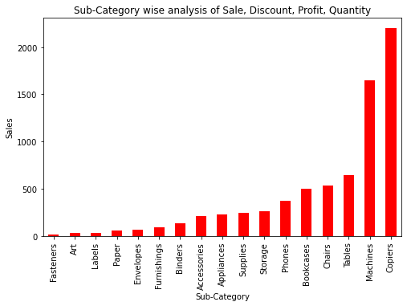

```python
df_scategory['Sales'].plot(kind='bar',figsize=(8,5),color = 'Red')
plt.title('Sub-Category wise analysis of Sale, Discount, Profit, Quantity')
plt.xlabel('Sub-Category')
plt.ylabel('Sales')
```

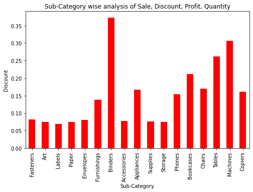

```python
df_scategory['Discount'].plot(kind='bar',figsize=(8,5),color = 'Red')
plt.title('Sub-Category wise analysis of Sale, Discount, Profit, Quantity')
plt.xlabel('Sub-Category')
plt.ylabel('Discount')
```

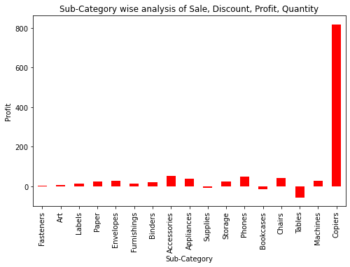

```python
df_scategory['Profit'].plot(kind='bar',figsize=(8,5),color = 'Red')
plt.title('Sub-Category wise analysis of Sale, Discount, Profit, Quantity')
plt.xlabel('Sub-Category')
plt.ylabel('Profit')
```

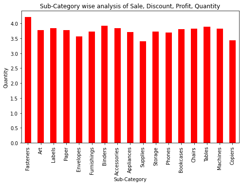

```python
df_scategory['Quantity'].plot(kind='bar',figsize=(8,5),color = 'Red')
plt.title('Sub-Category wise analysis of Sale, Discount, Profit, Quantity')
plt.xlabel('Sub-Category')
plt.ylabel('Quantity')
```

Supplies - low quantity  
Tables- low profit  
Can increase quantity, cost per piece to increase sales and reduce discount.  
Labels - low discount  
Fastners - low sales but not so much profitable, can reduce discount and increse cost/product because they are selling the highest no of products